# ANCOVA in Vocabulario Não Ensinado (Vocabulario Não Ensinado)

Geiser C. Challco geiser@alumni.usp.br

- Descriptive Statistics of Initial Data
- ANCOVA and Pairwise for one factor: **grupo**
  - Without remove non-normal data
  - Computing ANCOVA and PairWise After removing non-normal data (OK)
    - Plots for ancova
    - Checking linearity assumption
    - Checking normality and homogeneity
- ANCOVA and Pairwise for two factors **grupo:Sexo**
  - Without remove non-normal data
  - Computing ANCOVA and PairWise After removing non-normal data (OK)
    - Plots for ancova
    - Checking linearity assumption
    - Checking normality and homogeneity
- ANCOVA and Pairwise for two factors **grupo:Zona**
  - Without remove non-normal data
  - Computing ANCOVA and PairWise After removing non-normal data (OK)
    - Plots for ancova
    - Checking linearity assumption
    - Checking normality and homogeneity
- ANCOVA and Pairwise for two factors **grupo:Cor.Raca**
  - Without remove non-normal data
  - Computing ANCOVA and PairWise After removing non-normal data (OK)
    - Plots for ancova
    - Checking linearity assumption
    - Checking normality and homogeneity
- ANCOVA and Pairwise for two factors **grupo:vocab.non.teach.quintile**
  - Without remove non-normal data
  - Computing ANCOVA and PairWise After removing non-normal data (OK)
    - Plots for ancova
    - Checking linearity assumption
    - Checking normality and homogeneity
- Summary of Results
  - Descriptive Statistics
  - ANCOVA Table Comparison
  - PairWise Table Comparison
  - EMMS Table Comparison

**NOTE**:

- Teste ANCOVA para determinar se houve diferenças significativas no Vocabulario Não Ensinado (medido usando pre- e pos-testes).
- ANCOVA test to determine whether there were significant differences in Vocabulario Não Ensinado (measured using pre- and post-tests).

# Descriptive Statistics of Initial Data

```r
df <- get.descriptives(dat, c(dv.pre, dv.pos), c("grupo"),
                       include.global = T, symmetry.test = T, normality.test = F)
df <- plyr::rbind.fill(
  df, do.call(plyr::rbind.fill, lapply(lfatores2, FUN = function(f) {
    if (nrow(dat) > 0 && sum(!is.na(unique(dat[[f]]))) > 1)
      get.descriptives(dat, c(dv.pre,dv.pos), c("grupo", f),
                       symmetry.test = T, normality.test = F)
    }))
)
(df <- df[,c(fatores1[fatores1 %in% colnames(df)],"variable",
             colnames(df)[!colnames(df) %in% c(fatores1,"variable")])])
```

```
##           grupo Sexo   Zona Cor.Raca vocab.non.teach.quintile            variable   n   mean median min max
## 1      Controle <NA>   <NA>     <NA>                     <NA> vocab.non.teach.pre 146 17.425   17.0   1  34
## 2  Experimental <NA>   <NA>     <NA>                     <NA> vocab.non.teach.pre 165 18.758   19.0   3  34
## 3          <NA> <NA>   <NA>     <NA>                     <NA> vocab.non.teach.pre 311 18.132   18.0   1  34
## 4      Controle <NA>   <NA>     <NA>                     <NA> vocab.non.teach.pos 146 18.253   18.0   2  35
## 5  Experimental <NA>   <NA>     <NA>                     <NA> vocab.non.teach.pos 165 19.673   19.0   2  34
## 6          <NA> <NA>   <NA>     <NA>                     <NA> vocab.non.teach.pos 311 19.006   19.0   2  35
## 7      Controle    F   <NA>     <NA>                     <NA> vocab.non.teach.pre  65 18.785   19.0   5  31
## 8      Controle    M   <NA>     <NA>                     <NA> vocab.non.teach.pre  81 16.333   15.0   1  34
## 9  Experimental    F   <NA>     <NA>                     <NA> vocab.non.teach.pre  88 19.977   21.0   3  34
## 10 Experimental    M   <NA>     <NA>                     <NA> vocab.non.teach.pre  77 17.364   17.0   5  32
## 11     Controle    F   <NA>     <NA>                     <NA> vocab.non.teach.pos  65 20.262   20.0   4  35
## 12     Controle    M   <NA>     <NA>                     <NA> vocab.non.teach.pos  81 16.642   17.0   2  33
## 13 Experimental    F   <NA>     <NA>                     <NA> vocab.non.teach.pos  88 20.898   21.5   2  34
## 14 Experimental    M   <NA>     <NA>                     <NA> vocab.non.teach.pos  77 18.273   17.0   5  32
```

[output cut: 98 more lines]

| grupo | Sexo | Zona | Cor.Raca | vocab.non.teach.quintile | variable | n | mean | median | min | max | sd | se | ci | iqr | symmetry | skewness | kurtosis |
| --- | --- | --- | --- | --- | --- | --- | --- | --- | --- | --- | --- | --- | --- | --- | --- | --- | --- |
| Controle |  |  |  |  | vocab.non.teach.pre | 146 | 17.425 | 17.0 | 1 | 34 | 7.582 | 0.627 | 1.240 | 12.00 | YES | 0.177 | -0.906 |
| Experimental |  |  |  |  | vocab.non.teach.pre | 165 | 18.758 | 19.0 | 3 | 34 | 7.421 | 0.578 | 1.141 | 12.00 | YES | -0.059 | -1.007 |
|  |  |  |  |  | vocab.non.teach.pre | 311 | 18.132 | 18.0 | 1 | 34 | 7.515 | 0.426 | 0.838 | 12.00 | YES | 0.050 | -0.971 |
| Controle |  |  |  |  | vocab.non.teach.pos | 146 | 18.253 | 18.0 | 2 | 35 | 7.876 | 0.652 | 1.288 | 12.00 | YES | 0.060 | -0.947 |
| Experimental |  |  |  |  | vocab.non.teach.pos | 165 | 19.673 | 19.0 | 2 | 34 | 7.535 | 0.587 | 1.158 | 13.00 | YES | -0.038 | -0.985 |
|  |  |  |  |  | vocab.non.teach.pos | 311 | 19.006 | 19.0 | 2 | 35 | 7.717 | 0.438 | 0.861 | 12.00 | YES | -0.001 | -0.950 |
| Controle | F |  |  |  | vocab.non.teach.pre | 65 | 18.785 | 19.0 | 5 | 31 | 7.190 | 0.892 | 1.782 | 12.00 | YES | 0.041 | -1.050 |
| Controle | M |  |  |  | vocab.non.teach.pre | 81 | 16.333 | 15.0 | 1 | 34 | 7.754 | 0.862 | 1.715 | 13.00 | YES | 0.331 | -0.783 |
| Experimental | F |  |  |  | vocab.non.teach.pre | 88 | 19.977 | 21.0 | 3 | 34 | 7.614 | 0.812 | 1.613 | 9.50 | YES | -0.411 | -0.757 |
| Experimental | M |  |  |  | vocab.non.teach.pre | 77 | 17.364 | 17.0 | 5 | 32 | 6.985 | 0.796 | 1.585 | 11.00 | YES | 0.347 | -0.960 |
| Controle | F |  |  |  | vocab.non.teach.pos | 65 | 20.262 | 20.0 | 4 | 35 | 7.276 | 0.903 | 1.803 | 11.00 | YES | -0.055 | -0.922 |
| Controle | M |  |  |  | vocab.non.teach.pos | 81 | 16.642 | 17.0 | 2 | 33 | 8.011 | 0.890 | 1.771 | 13.00 | YES | 0.238 | -0.943 |
| Experimental | F |  |  |  | vocab.non.teach.pos | 88 | 20.898 | 21.5 | 2 | 34 | 7.667 | 0.817 | 1.624 | 12.25 | YES | -0.242 | -0.868 |
| Experimental | M |  |  |  | vocab.non.teach.pos | 77 | 18.273 | 17.0 | 5 | 32 | 7.176 | 0.818 | 1.629 | 13.00 | YES | 0.162 | -1.023 |
| Controle |  | Rural |  |  | vocab.non.teach.pre | 97 | 18.062 | 18.0 | 1 | 31 | 7.222 | 0.733 | 1.456 | 11.00 | YES | -0.096 | -0.883 |
| Controle |  | Urbana |  |  | vocab.non.teach.pre | 28 | 19.250 | 17.5 | 6 | 34 | 8.910 | 1.684 | 3.455 | 15.00 | YES | 0.165 | -1.432 |
| Controle |  |  |  |  | vocab.non.teach.pre | 21 | 12.048 | 11.0 | 4 | 20 | 4.717 | 1.029 | 2.147 | 7.00 | YES | 0.203 | -1.145 |
| Experimental |  | Rural |  |  | vocab.non.teach.pre | 85 | 17.812 | 18.0 | 3 | 34 | 7.072 | 0.767 | 1.525 | 12.00 | YES | -0.002 | -0.881 |
| Experimental |  | Urbana |  |  | vocab.non.teach.pre | 38 | 19.921 | 21.0 | 6 | 31 | 7.441 | 1.207 | 2.446 | 11.75 | YES | -0.204 | -1.213 |
| Experimental |  |  |  |  | vocab.non.teach.pre | 42 | 19.619 | 20.5 | 5 | 33 | 8.000 | 1.234 | 2.493 | 12.50 | YES | -0.127 | -1.187 |
| Controle |  | Rural |  |  | vocab.non.teach.pos | 97 | 18.742 | 19.0 | 2 | 35 | 8.068 | 0.819 | 1.626 | 14.00 | YES | -0.073 | -1.010 |
| Controle |  | Urbana |  |  | vocab.non.teach.pos | 28 | 20.286 | 19.5 | 4 | 32 | 7.581 | 1.433 | 2.940 | 11.75 | YES | -0.037 | -1.022 |
| Controle |  |  |  |  | vocab.non.teach.pos | 21 | 13.286 | 13.0 | 5 | 22 | 5.188 | 1.132 | 2.362 | 8.00 | YES | 0.061 | -1.213 |
| Experimental |  | Rural |  |  | vocab.non.teach.pos | 85 | 18.741 | 18.0 | 2 | 32 | 6.922 | 0.751 | 1.493 | 12.00 | YES | 0.045 | -0.726 |
| Experimental |  | Urbana |  |  | vocab.non.teach.pos | 38 | 20.816 | 21.0 | 5 | 33 | 7.756 | 1.258 | 2.549 | 13.50 | YES | -0.134 | -1.243 |
| Experimental |  |  |  |  | vocab.non.teach.pos | 42 | 20.524 | 21.5 | 5 | 34 | 8.420 | 1.299 | 2.624 | 14.25 | YES | -0.214 | -1.253 |
| Controle |  |  | Branca |  | vocab.non.teach.pre | 22 | 19.227 | 20.0 | 7 | 30 | 6.241 | 1.331 | 2.767 | 7.00 | NO | -0.586 | -0.568 |
| Controle |  |  | Indígena |  | vocab.non.teach.pre | 2 | 18.500 | 18.5 | 17 | 20 | 2.121 | 1.500 | 19.059 | 1.50 | few data | 0.000 | 0.000 |
| Controle |  |  | Parda |  | vocab.non.teach.pre | 42 | 17.429 | 15.5 | 6 | 31 | 7.790 | 1.202 | 2.428 | 11.75 | YES | 0.366 | -1.135 |
| Controle |  |  | Preta |  | vocab.non.teach.pre | 1 | 16.000 | 16.0 | 16 | 16 |  |  |  | 0.00 | few data | 0.000 | 0.000 |
| Controle |  |  |  |  | vocab.non.teach.pre | 79 | 16.911 | 16.0 | 1 | 34 | 7.949 | 0.894 | 1.780 | 13.00 | YES | 0.256 | -0.908 |
| Experimental |  |  | Branca |  | vocab.non.teach.pre | 18 | 20.778 | 21.5 | 10 | 32 | 6.620 | 1.560 | 3.292 | 7.00 | YES | -0.050 | -1.070 |
| Experimental |  |  | Indígena |  | vocab.non.teach.pre | 13 | 17.000 | 18.0 | 7 | 30 | 7.000 | 1.941 | 4.230 | 10.00 | YES | 0.257 | -1.343 |
| Experimental |  |  | Parda |  | vocab.non.teach.pre | 44 | 17.932 | 18.5 | 3 | 30 | 6.970 | 1.051 | 2.119 | 10.50 | YES | -0.131 | -1.063 |
| Experimental |  |  | Preta |  | vocab.non.teach.pre | 1 | 9.000 | 9.0 | 9 | 9 |  |  |  | 0.00 | few data | 0.000 | 0.000 |
| Experimental |  |  |  |  | vocab.non.teach.pre | 89 | 19.124 | 20.0 | 5 | 34 | 7.804 | 0.827 | 1.644 | 12.00 | YES | -0.098 | -1.072 |
| Controle |  |  | Branca |  | vocab.non.teach.pos | 22 | 19.455 | 20.5 | 8 | 32 | 7.282 | 1.552 | 3.228 | 10.75 | YES | -0.191 | -1.156 |
| Controle |  |  | Indígena |  | vocab.non.teach.pos | 2 | 24.000 | 24.0 | 24 | 24 | 0.000 | 0.000 | 0.000 | 0.00 | few data | 0.000 | 0.000 |
| Controle |  |  | Parda |  | vocab.non.teach.pos | 42 | 17.929 | 17.0 | 4 | 32 | 8.292 | 1.279 | 2.584 | 14.75 | YES | 0.112 | -1.391 |
| Controle |  |  | Preta |  | vocab.non.teach.pos | 1 | 18.000 | 18.0 | 18 | 18 |  |  |  | 0.00 | few data | 0.000 | 0.000 |
| Controle |  |  |  |  | vocab.non.teach.pos | 79 | 17.949 | 18.0 | 2 | 35 | 7.969 | 0.897 | 1.785 | 10.00 | YES | 0.152 | -0.732 |
| Experimental |  |  | Branca |  | vocab.non.teach.pos | 18 | 19.722 | 19.0 | 5 | 33 | 9.228 | 2.175 | 4.589 | 15.25 | YES | 0.058 | -1.542 |
| Experimental |  |  | Indígena |  | vocab.non.teach.pos | 13 | 19.538 | 18.0 | 10 | 30 | 7.310 | 2.027 | 4.417 | 14.00 | YES | 0.257 | -1.622 |
| Experimental |  |  | Parda |  | vocab.non.teach.pos | 44 | 19.545 | 19.5 | 8 | 32 | 6.504 | 0.980 | 1.977 | 10.25 | YES | -0.135 | -1.081 |
| Experimental |  |  | Preta |  | vocab.non.teach.pos | 1 | 9.000 | 9.0 | 9 | 9 |  |  |  | 0.00 | few data | 0.000 | 0.000 |
| Experimental |  |  |  |  | vocab.non.teach.pos | 89 | 19.865 | 20.0 | 2 | 34 | 7.749 | 0.821 | 1.632 | 12.00 | YES | -0.103 | -0.920 |
| Controle |  |  |  | 1st quintile | vocab.non.teach.pre | 50 | 9.180 | 9.0 | 1 | 13 | 2.753 | 0.389 | 0.782 | 4.00 | YES | -0.494 | -0.092 |
| Controle |  |  |  | 2nd quintile | vocab.non.teach.pre | 39 | 16.462 | 16.0 | 14 | 19 | 1.790 | 0.287 | 0.580 | 3.00 | YES | 0.007 | -1.396 |
| Controle |  |  |  | 3rd quintile | vocab.non.teach.pre | 29 | 22.069 | 22.0 | 20 | 24 | 1.602 | 0.297 | 0.609 | 3.00 | YES | -0.058 | -1.682 |
| Controle |  |  |  | 4th quintile | vocab.non.teach.pre | 16 | 26.938 | 27.0 | 25 | 29 | 1.482 | 0.370 | 0.790 | 2.25 | YES | -0.016 | -1.496 |
| Controle |  |  |  | 5th quintile | vocab.non.teach.pre | 12 | 31.000 | 31.0 | 30 | 34 | 1.279 | 0.369 | 0.813 | 1.00 | NO | 1.194 | 0.174 |
| Experimental |  |  |  | 1st quintile | vocab.non.teach.pre | 51 | 9.784 | 10.0 | 3 | 13 | 2.610 | 0.365 | 0.734 | 4.00 | NO | -0.549 | -0.694 |
| Experimental |  |  |  | 2nd quintile | vocab.non.teach.pre | 33 | 16.970 | 17.0 | 14 | 19 | 1.828 | 0.318 | 0.648 | 3.00 | YES | -0.462 | -1.213 |
| Experimental |  |  |  | 3rd quintile | vocab.non.teach.pre | 40 | 22.125 | 22.0 | 20 | 24 | 1.539 | 0.243 | 0.492 | 3.00 | YES | -0.039 | -1.542 |
| Experimental |  |  |  | 4th quintile | vocab.non.teach.pre | 29 | 26.759 | 26.0 | 25 | 29 | 1.640 | 0.305 | 0.624 | 4.00 | YES | 0.328 | -1.594 |
| Experimental |  |  |  | 5th quintile | vocab.non.teach.pre | 12 | 31.250 | 31.0 | 30 | 34 | 1.422 | 0.411 | 0.904 | 2.25 | NO | 0.641 | -1.198 |
| Controle |  |  |  | 1st quintile | vocab.non.teach.pos | 50 | 11.100 | 11.0 | 2 | 20 | 4.220 | 0.597 | 1.199 | 6.00 | YES | -0.041 | -0.490 |
| Controle |  |  |  | 2nd quintile | vocab.non.teach.pos | 39 | 16.821 | 18.0 | 4 | 27 | 5.693 | 0.912 | 1.846 | 7.50 | YES | -0.220 | -0.687 |
| Controle |  |  |  | 3rd quintile | vocab.non.teach.pos | 29 | 22.966 | 22.0 | 17 | 35 | 4.822 | 0.895 | 1.834 | 4.00 | NO | 0.945 | 0.032 |
| Controle |  |  |  | 4th quintile | vocab.non.teach.pos | 16 | 26.875 | 27.5 | 21 | 31 | 2.705 | 0.676 | 1.441 | 3.25 | NO | -0.672 | -0.458 |
| Controle |  |  |  | 5th quintile | vocab.non.teach.pos | 12 | 29.833 | 30.5 | 26 | 32 | 2.125 | 0.613 | 1.350 | 2.75 | NO | -0.583 | -1.296 |
| Experimental |  |  |  | 1st quintile | vocab.non.teach.pos | 51 | 13.588 | 13.0 | 2 | 32 | 5.404 | 0.757 | 1.520 | 7.00 | NO | 0.785 | 1.380 |
| Experimental |  |  |  | 2nd quintile | vocab.non.teach.pos | 33 | 17.212 | 18.0 | 5 | 27 | 5.436 | 0.946 | 1.927 | 6.00 | YES | -0.368 | -0.451 |
| Experimental |  |  |  | 3rd quintile | vocab.non.teach.pos | 40 | 22.050 | 23.0 | 11 | 33 | 5.773 | 0.913 | 1.846 | 7.25 | YES | -0.382 | -0.778 |
| Experimental |  |  |  | 4th quintile | vocab.non.teach.pos | 29 | 25.621 | 27.0 | 8 | 32 | 5.137 | 0.954 | 1.954 | 3.00 | NO | -1.588 | 2.821 |
| Experimental |  |  |  | 5th quintile | vocab.non.teach.pos | 12 | 30.000 | 32.0 | 17 | 34 | 4.729 | 1.365 | 3.005 | 2.50 | NO | -1.711 | 1.944 |

# ANCOVA and Pairwise for one factor: **grupo**

## Without remove non-normal data

```r
pdat = remove_group_data(dat[!is.na(dat[["grupo"]]),], "vocab.non.teach.pos", "grupo")

pdat.long <- rbind(pdat[,c("id","grupo")], pdat[,c("id","grupo")])
pdat.long[["time"]] <- c(rep("pre", nrow(pdat)), rep("pos", nrow(pdat)))
pdat.long[["time"]] <- factor(pdat.long[["time"]], c("pre","pos"))
pdat.long[["vocab.non.teach"]] <- c(pdat[["vocab.non.teach.pre"]], pdat[["vocab.non.teach.pos"]])

aov = anova_test(pdat, vocab.non.teach.pos ~ vocab.non.teach.pre + grupo)
laov[["grupo"]] <- get_anova_table(aov)
```

```r
pwc <- emmeans_test(pdat, vocab.non.teach.pos ~ grupo, covariate = vocab.non.teach.pre,
                    p.adjust.method = "bonferroni")
```

```r
pwc.long <- emmeans_test(dplyr::group_by_at(pdat.long, "grupo"),
                          vocab.non.teach ~ time,
                          p.adjust.method = "bonferroni")
lpwc[["grupo"]] <- plyr::rbind.fill(pwc, pwc.long)
```

```r
ds <- get.descriptives(pdat, "vocab.non.teach.pos", "grupo", covar = "vocab.non.teach.pre")
ds <- merge(ds[ds$variable != "vocab.non.teach.pre",],
            ds[ds$variable == "vocab.non.teach.pre", !colnames(ds) %in% c("variable")],
            by = "grupo", all.x = T, suffixes = c("", ".vocab.non.teach.pre"))
ds <- merge(get_emmeans(pwc), ds, by = "grupo", suffixes = c(".emms", ""))
ds <- ds[,c("grupo","n","mean.vocab.non.teach.pre","se.vocab.non.teach.pre","mean","se","emmean","se.emms")]

colnames(ds) <- c("grupo", "N", paste0(c("M","SE")," (pre)"),
                  paste0(c("M","SE"), " (unadj)"), paste0(c("M", "SE"), " (adj)"))

lemms[["grupo"]] <- ds
```

## Computing ANCOVA and PairWise After removing non-normal data (OK)

```r
wdat = pdat

res = residuals(lm(vocab.non.teach.pos ~ vocab.non.teach.pre + grupo, data = wdat))
non.normal = getNonNormal(res, wdat$id, plimit = 0.05)

wdat = wdat[!wdat$id %in% non.normal,]

wdat.long <- rbind(wdat[,c("id","grupo")], wdat[,c("id","grupo")])
wdat.long[["time"]] <- c(rep("pre", nrow(wdat)), rep("pos", nrow(wdat)))
wdat.long[["time"]] <- factor(wdat.long[["time"]], c("pre","pos"))
wdat.long[["vocab.non.teach"]] <- c(wdat[["vocab.non.teach.pre"]], wdat[["vocab.non.teach.pos"]])

ldat[["grupo"]] = wdat

(non.normal)
```

```
## [1] "P1790" "P852"  "P2853" "P3473" "P2850" "P3471" "P478"  "P888"
```

```r
aov = anova_test(wdat, vocab.non.teach.pos ~ vocab.non.teach.pre + grupo)
laov[["grupo"]] <- merge(get_anova_table(aov), laov[["grupo"]], by="Effect", suffixes = c("","'"))

(df = get_anova_table(aov))
```

```
## ANOVA Table (type II tests)
##
##                Effect DFn DFd       F        p p<.05   ges
## 1 vocab.non.teach.pre   1 300 595.851 3.05e-73     * 0.665
## 2               grupo   1 300   0.581 4.46e-01       0.002
```

| Effect | DFn | DFd | F | p | p<.05 | ges |
| --- | --- | --- | --- | --- | --- | --- |
| vocab.non.teach.pre | 1 | 300 | 595.851 | 0.000 | * | 0.665 |
| grupo | 1 | 300 | 0.581 | 0.446 |  | 0.002 |

| term | .y. | group1 | group2 | df | statistic | p | p.adj | p.adj.signif |
| --- | --- | --- | --- | --- | --- | --- | --- | --- |
| vocab.non.teach.pre*grupo | vocab.non.teach.pos | Controle | Experimental | 300 | -0.762 | 0.446 | 0.446 | ns |

```r
pwc.long <- emmeans_test(dplyr::group_by_at(wdat.long, "grupo"),
                         vocab.non.teach ~ time,
                         p.adjust.method = "bonferroni")
lpwc[["grupo"]] <- merge(plyr::rbind.fill(pwc, pwc.long), lpwc[["grupo"]], by=c("grupo","term",".y.","group1","group2"), suffixes = c("","'"))
```

| grupo | term | .y. | group1 | group2 | df | statistic | p | p.adj | p.adj.signif |
| --- | --- | --- | --- | --- | --- | --- | --- | --- | --- |
| Controle | time | vocab.non.teach | pre | pos | 602 | -1.022 | 0.307 | 0.307 | ns |
| Experimental | time | vocab.non.teach | pre | pos | 602 | -1.254 | 0.210 | 0.210 | ns |

```r
ds <- get.descriptives(wdat, "vocab.non.teach.pos", "grupo", covar = "vocab.non.teach.pre")
ds <- merge(ds[ds$variable != "vocab.non.teach.pre",],
            ds[ds$variable == "vocab.non.teach.pre", !colnames(ds) %in% c("variable")],
            by = "grupo", all.x = T, suffixes = c("", ".vocab.non.teach.pre"))
ds <- merge(get_emmeans(pwc), ds, by = "grupo", suffixes = c(".emms", ""))
ds <- ds[,c("grupo","n","mean.vocab.non.teach.pre","se.vocab.non.teach.pre","mean","se","emmean","se.emms")]

colnames(ds) <- c("grupo", "N", paste0(c("M","SE")," (pre)"),
                  paste0(c("M","SE"), " (unadj)"), paste0(c("M", "SE"), " (adj)"))

lemms[["grupo"]] <- merge(ds, lemms[["grupo"]], by=c("grupo"), suffixes = c("","'"))
```

| grupo | N | M (pre) | SE (pre) | M (unadj) | SE (unadj) | M (adj) | SE (adj) |
| --- | --- | --- | --- | --- | --- | --- | --- |
| Controle | 145 | 17.414 | 0.632 | 18.324 | 0.652 | 18.909 | 0.369 |
| Experimental | 158 | 18.766 | 0.591 | 19.835 | 0.592 | 19.299 | 0.353 |

### Plots for ancova

```r
plots <- oneWayAncovaPlots(
  wdat, "vocab.non.teach.pos", "grupo", aov, list("grupo"=pwc), addParam = c("mean_se"),
  font.label.size=10, step.increase=0.05, p.label="p.adj",
  subtitle = which(aov$Effect == "grupo"))
```

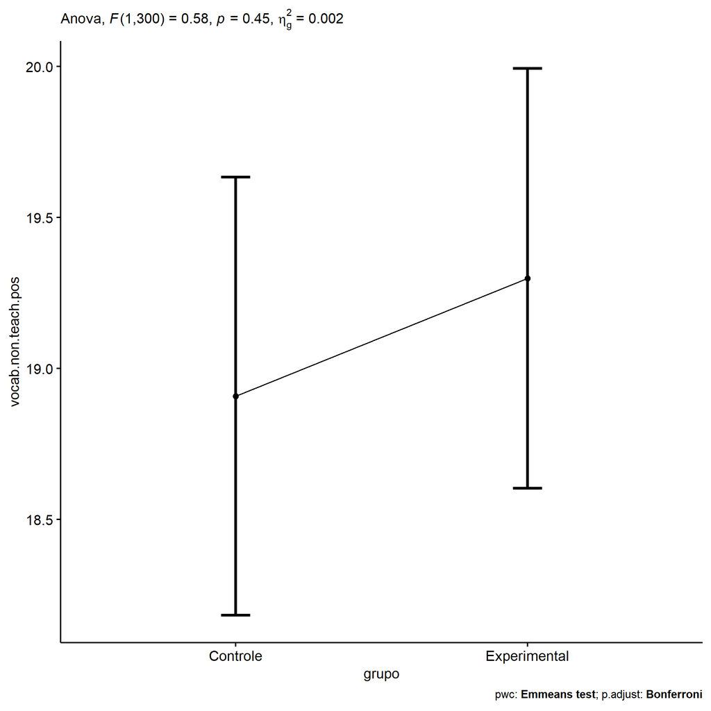

```r
if (!is.null(nrow(plots[["grupo"]]$data)))
  plots[["grupo"]] + ggplot2::scale_color_manual(values = color[["grupo"]])
```

```r
plots <- oneWayAncovaBoxPlots(
  wdat, "vocab.non.teach.pos", "grupo", aov, pwc, covar = "vocab.non.teach.pre",
  theme = "classic", color = color[["grupo"]],
  subtitle = which(aov$Effect == "grupo"))
```

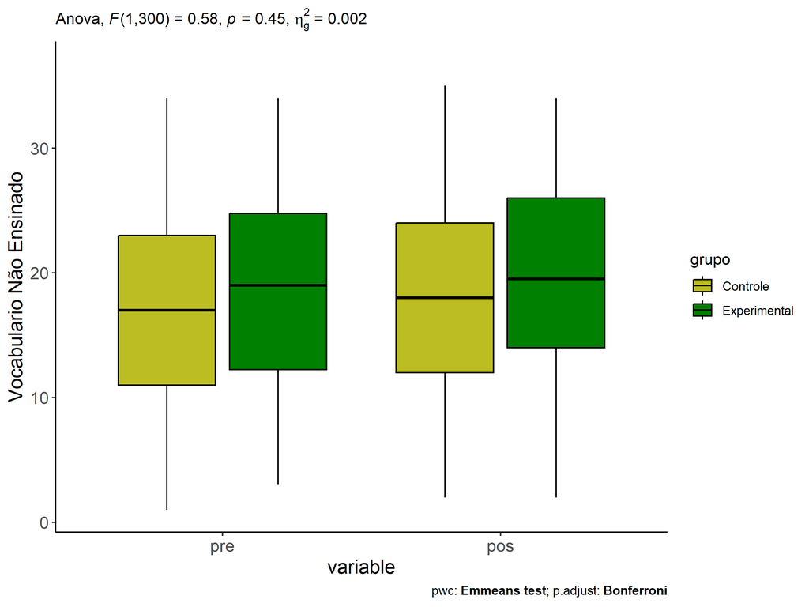

```r
if (length(unique(wdat[["grupo"]])) > 1)
  plots[["grupo"]] + ggplot2::ylab("Vocabulario Não Ensinado") + ggplot2::scale_x_discrete(labels=c('pre', 'pos'))
```

```r
if (length(unique(wdat.long[["grupo"]])) > 1)
  plots <- oneWayAncovaBoxPlots(
    wdat.long, "vocab.non.teach", "grupo", aov, pwc.long, pre.post = "time",
    theme = "classic", color = color$prepost)
```

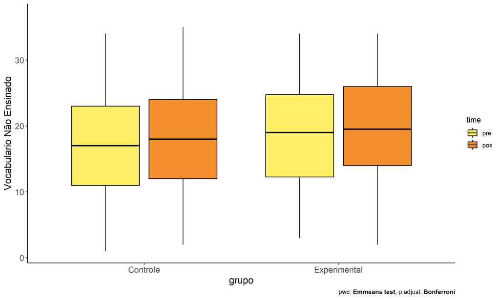

```r
if (length(unique(wdat.long[["grupo"]])) > 1)
  plots[["grupo"]] + ggplot2::ylab("Vocabulario Não Ensinado")
```

### Checking linearity assumption

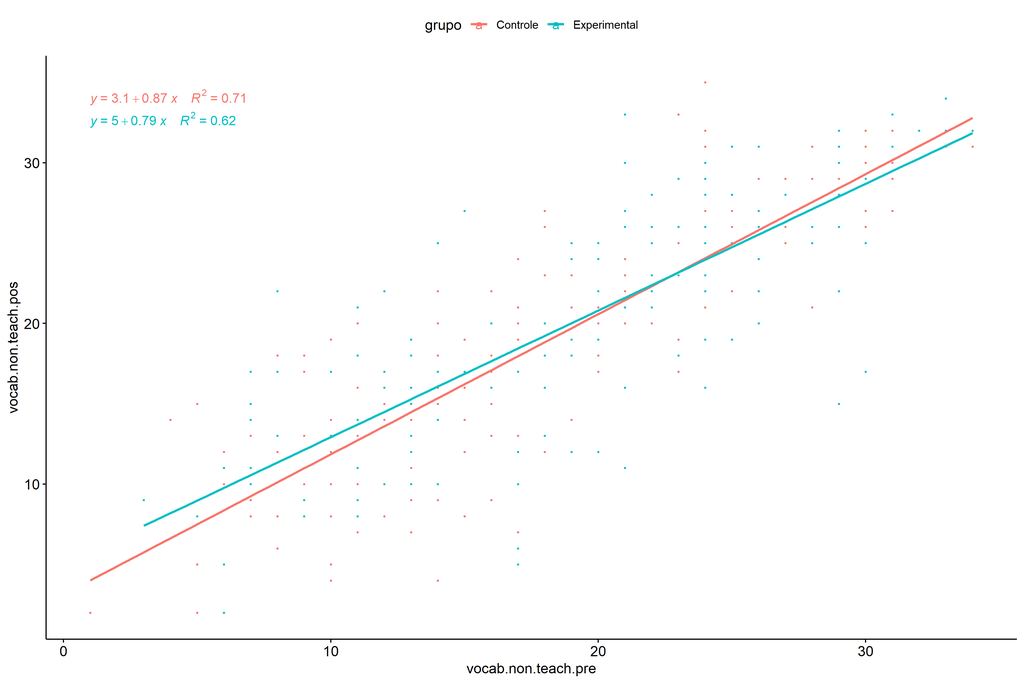

```r
ggscatter(wdat, x = "vocab.non.teach.pre", y = "vocab.non.teach.pos", size = 0.5,
          color = "grupo", add = "reg.line")+
  stat_regline_equation(
    aes(label =  paste(..eq.label.., ..rr.label.., sep = "~~~~"), color = grupo)
  )
```

### Checking normality and homogeneity

```r
res <- augment(lm(vocab.non.teach.pos ~ vocab.non.teach.pre + grupo, data = wdat))
```

```r
shapiro_test(res$.resid)
```

```
## # A tibble: 1 × 3
##   variable   statistic p.value
##   <chr>          <dbl>   <dbl>
## 1 res$.resid     0.990  0.0364
```

```r
levene_test(res, .resid ~ grupo)
```

```
## # A tibble: 1 × 4
##     df1   df2 statistic     p
##   <int> <int>     <dbl> <dbl>
## 1     1   301     0.621 0.431
```

# ANCOVA and Pairwise for two factors **grupo:Sexo**

## Without remove non-normal data

```r
pdat = remove_group_data(dat[!is.na(dat[["grupo"]]) & !is.na(dat[["Sexo"]]),], "vocab.non.teach.pos", c("grupo","Sexo"))

pdat.long <- rbind(pdat[,c("id","grupo","Sexo")], pdat[,c("id","grupo","Sexo")])
pdat.long[["time"]] <- c(rep("pre", nrow(pdat)), rep("pos", nrow(pdat)))
pdat.long[["time"]] <- factor(pdat.long[["time"]], c("pre","pos"))
pdat.long[["vocab.non.teach"]] <- c(pdat[["vocab.non.teach.pre"]], pdat[["vocab.non.teach.pos"]])

aov = anova_test(pdat, vocab.non.teach.pos ~ vocab.non.teach.pre + grupo*Sexo)
laov[["grupo:Sexo"]] <- get_anova_table(aov)
```

```r
pwcs <- list()
pwcs[["Sexo"]] <- emmeans_test(
  group_by(pdat, grupo), vocab.non.teach.pos ~ Sexo,
  covariate = vocab.non.teach.pre, p.adjust.method = "bonferroni")
pwcs[["grupo"]] <- emmeans_test(
  group_by(pdat, Sexo), vocab.non.teach.pos ~ grupo,
  covariate = vocab.non.teach.pre, p.adjust.method = "bonferroni")

pwc <- plyr::rbind.fill(pwcs[["grupo"]], pwcs[["Sexo"]])
pwc <- pwc[,c("grupo","Sexo", colnames(pwc)[!colnames(pwc) %in% c("grupo","Sexo")])]
```

```r
pwc.long <- emmeans_test(dplyr::group_by_at(pdat.long, c("grupo","Sexo")),
                         vocab.non.teach ~ time,
                         p.adjust.method = "bonferroni")
lpwc[["grupo:Sexo"]] <- plyr::rbind.fill(pwc, pwc.long)
```

```r
ds <- get.descriptives(pdat, "vocab.non.teach.pos", c("grupo","Sexo"), covar = "vocab.non.teach.pre")
ds <- merge(ds[ds$variable != "vocab.non.teach.pre",],
            ds[ds$variable == "vocab.non.teach.pre", !colnames(ds) %in% c("variable")],
            by = c("grupo","Sexo"), all.x = T, suffixes = c("", ".vocab.non.teach.pre"))
ds <- merge(get_emmeans(pwcs[["grupo"]]), ds, by = c("grupo","Sexo"), suffixes = c(".emms", ""))
ds <- ds[,c("grupo","Sexo","n","mean.vocab.non.teach.pre","se.vocab.non.teach.pre","mean","se","emmean","se.emms")]

colnames(ds) <- c("grupo","Sexo", "N", paste0(c("M","SE")," (pre)"),
                  paste0(c("M","SE"), " (unadj)"), paste0(c("M", "SE"), " (adj)"))

lemms[["grupo:Sexo"]] <- ds
```

## Computing ANCOVA and PairWise After removing non-normal data (OK)

```r
wdat = pdat

res = residuals(lm(vocab.non.teach.pos ~ vocab.non.teach.pre + grupo*Sexo, data = wdat))
non.normal = getNonNormal(res, wdat$id, plimit = 0.05)

wdat = wdat[!wdat$id %in% non.normal,]

wdat.long <- rbind(wdat[,c("id","grupo","Sexo")], wdat[,c("id","grupo","Sexo")])
wdat.long[["time"]] <- c(rep("pre", nrow(wdat)), rep("pos", nrow(wdat)))
wdat.long[["time"]] <- factor(wdat.long[["time"]], c("pre","pos"))
wdat.long[["vocab.non.teach"]] <- c(wdat[["vocab.non.teach.pre"]], wdat[["vocab.non.teach.pos"]])


ldat[["grupo:Sexo"]] = wdat

(non.normal)
```

```
## [1] "P852"  "P1790" "P2853" "P3473" "P2850" "P478"  "P1794" "P1620"
```

```r
aov = anova_test(wdat, vocab.non.teach.pos ~ vocab.non.teach.pre + grupo*Sexo)
laov[["grupo:Sexo"]] <- merge(get_anova_table(aov), laov[["grupo:Sexo"]], by="Effect", suffixes = c("","'"))

(df = get_anova_table(aov))
```

```
## ANOVA Table (type II tests)
##
##                Effect DFn DFd       F        p p<.05     ges
## 1 vocab.non.teach.pre   1 298 577.787 9.88e-72     * 0.66000
## 2               grupo   1 298   0.836 3.61e-01       0.00300
## 3                Sexo   1 298   7.084 8.00e-03     * 0.02300
## 4          grupo:Sexo   1 298   0.224 6.37e-01       0.00075
```

| Effect | DFn | DFd | F | p | p<.05 | ges |
| --- | --- | --- | --- | --- | --- | --- |
| vocab.non.teach.pre | 1 | 298 | 577.787 | 0.000 | * | 0.660 |
| grupo | 1 | 298 | 0.836 | 0.361 |  | 0.003 |
| Sexo | 1 | 298 | 7.084 | 0.008 | * | 0.023 |
| grupo:Sexo | 1 | 298 | 0.224 | 0.637 |  | 0.001 |

```r
pwcs <- list()
pwcs[["Sexo"]] <- emmeans_test(
  group_by(wdat, grupo), vocab.non.teach.pos ~ Sexo,
  covariate = vocab.non.teach.pre, p.adjust.method = "bonferroni")
pwcs[["grupo"]] <- emmeans_test(
  group_by(wdat, Sexo), vocab.non.teach.pos ~ grupo,
  covariate = vocab.non.teach.pre, p.adjust.method = "bonferroni")

pwc <- plyr::rbind.fill(pwcs[["grupo"]], pwcs[["Sexo"]])
pwc <- pwc[,c("grupo","Sexo", colnames(pwc)[!colnames(pwc) %in% c("grupo","Sexo")])]
```

| grupo | Sexo | term | .y. | group1 | group2 | df | statistic | p | p.adj | p.adj.signif |
| --- | --- | --- | --- | --- | --- | --- | --- | --- | --- | --- |
|  | F | vocab.non.teach.pre*grupo | vocab.non.teach.pos | Controle | Experimental | 298 | -0.296 | 0.767 | 0.767 | ns |
|  | M | vocab.non.teach.pre*grupo | vocab.non.teach.pos | Controle | Experimental | 298 | -0.987 | 0.325 | 0.325 | ns |
| Controle |  | vocab.non.teach.pre*Sexo | vocab.non.teach.pos | F | M | 298 | 2.194 | 0.029 | 0.029 | * |
| Experimental |  | vocab.non.teach.pre*Sexo | vocab.non.teach.pos | F | M | 298 | 1.608 | 0.109 | 0.109 | ns |

```r
pwc.long <- emmeans_test(dplyr::group_by_at(wdat.long, c("grupo","Sexo")),
                         vocab.non.teach ~ time,
                         p.adjust.method = "bonferroni")
lpwc[["grupo:Sexo"]] <- merge(plyr::rbind.fill(pwc, pwc.long), lpwc[["grupo:Sexo"]], by=c("grupo","Sexo","term",".y.","group1","group2"), suffixes = c("","'"))
```

| grupo | Sexo | term | .y. | group1 | group2 | df | statistic | p | p.adj | p.adj.signif |
| --- | --- | --- | --- | --- | --- | --- | --- | --- | --- | --- |
| Controle | F | time | vocab.non.teach | pre | pos | 598 | -1.130 | 0.259 | 0.259 | ns |
| Controle | M | time | vocab.non.teach | pre | pos | 598 | -0.264 | 0.792 | 0.792 | ns |
| Experimental | F | time | vocab.non.teach | pre | pos | 598 | -1.289 | 0.198 | 0.198 | ns |
| Experimental | M | time | vocab.non.teach | pre | pos | 598 | -0.657 | 0.511 | 0.511 | ns |

```r
ds <- get.descriptives(wdat, "vocab.non.teach.pos", c("grupo","Sexo"), covar = "vocab.non.teach.pre")
ds <- merge(ds[ds$variable != "vocab.non.teach.pre",],
            ds[ds$variable == "vocab.non.teach.pre", !colnames(ds) %in% c("variable")],
            by = c("grupo","Sexo"), all.x = T, suffixes = c("", ".vocab.non.teach.pre"))
ds <- merge(get_emmeans(pwcs[["grupo"]]), ds, by = c("grupo","Sexo"), suffixes = c(".emms", ""))
ds <- ds[,c("grupo","Sexo","n","mean.vocab.non.teach.pre","se.vocab.non.teach.pre","mean","se","emmean","se.emms")]

colnames(ds) <- c("grupo","Sexo", "N", paste0(c("M","SE")," (pre)"),
                  paste0(c("M","SE"), " (unadj)"), paste0(c("M", "SE"), " (adj)"))

lemms[["grupo:Sexo"]] <- merge(ds, lemms[["grupo:Sexo"]], by=c("grupo","Sexo"), suffixes = c("","'"))
```

| grupo | Sexo | N | M (pre) | SE (pre) | M (unadj) | SE (unadj) | M (adj) | SE (adj) |
| --- | --- | --- | --- | --- | --- | --- | --- | --- |
| Controle | F | 65 | 18.785 | 0.892 | 20.262 | 0.903 | 19.691 | 0.543 |
| Controle | M | 81 | 16.333 | 0.862 | 16.642 | 0.890 | 18.082 | 0.490 |
| Experimental | F | 82 | 19.854 | 0.837 | 21.354 | 0.838 | 19.906 | 0.487 |
| Experimental | M | 75 | 17.453 | 0.813 | 18.253 | 0.802 | 18.775 | 0.506 |

### Plots for ancova

```r
plots <- twoWayAncovaPlots(
  wdat, "vocab.non.teach.pos", c("grupo","Sexo"), aov, pwcs, addParam = c("mean_se"),
  font.label.size=10, step.increase=0.05, p.label="p.adj",
  subtitle = which(aov$Effect == "grupo:Sexo"))
```

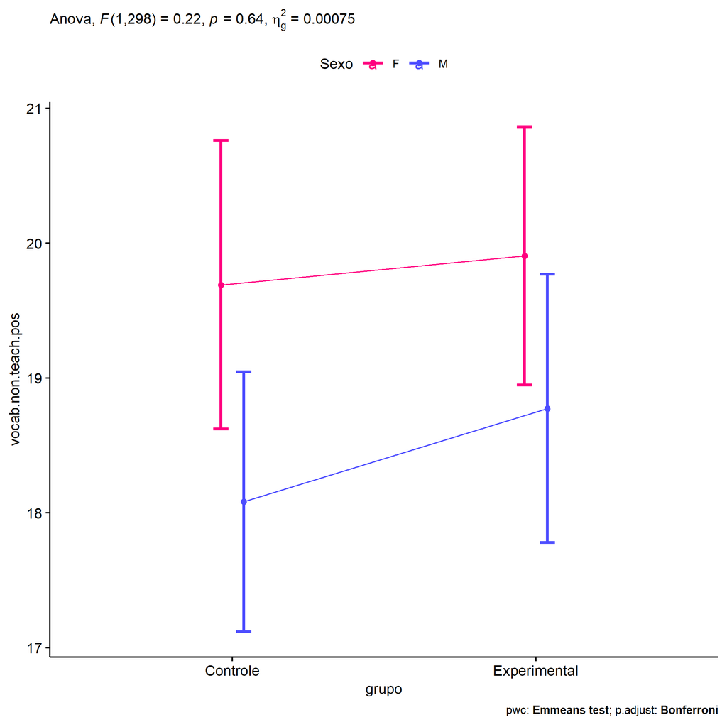

```r
if (!is.null(plots[["grupo"]]))
  plots[["grupo"]] + ggplot2::scale_color_manual(values = color[["Sexo"]])
```

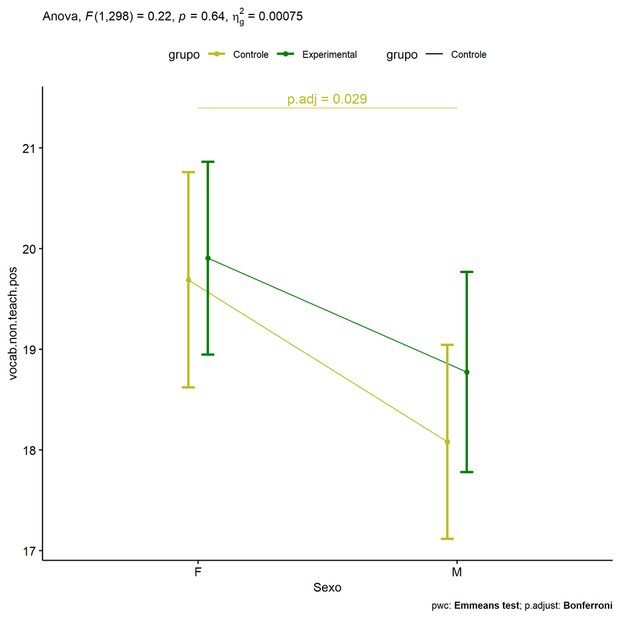

```r
if (!is.null(plots[["Sexo"]]))
  plots[["Sexo"]] + ggplot2::scale_color_manual(values = color[["grupo"]])
```

```r
plots <- twoWayAncovaBoxPlots(
  wdat, "vocab.non.teach.pos", c("grupo","Sexo"), aov, pwcs, covar = "vocab.non.teach.pre",
  theme = "classic", color = color[["grupo:Sexo"]],
  subtitle = which(aov$Effect == "grupo:Sexo"))
```

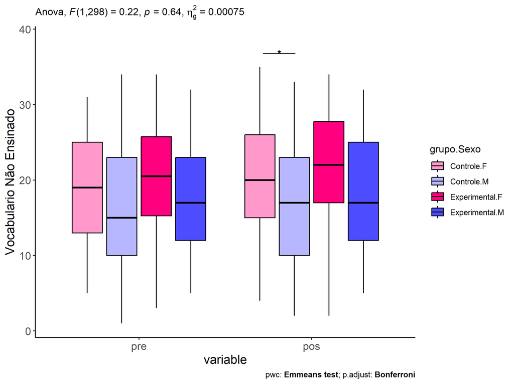

```r
plots[["grupo:Sexo"]] + ggplot2::ylab("Vocabulario Não Ensinado") + ggplot2::scale_x_discrete(labels=c('pre', 'pos'))
```

```r
plots <- twoWayAncovaBoxPlots(
  wdat.long, "vocab.non.teach", c("grupo","Sexo"), aov, pwc.long, pre.post = "time",
  theme = "classic", color = color$prepost)
```

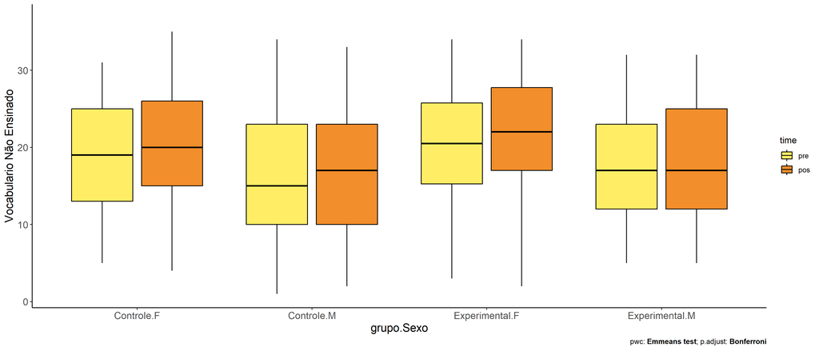

```r
plots[["grupo:Sexo"]] + ggplot2::ylab("Vocabulario Não Ensinado")
```

### Checking linearity assumption

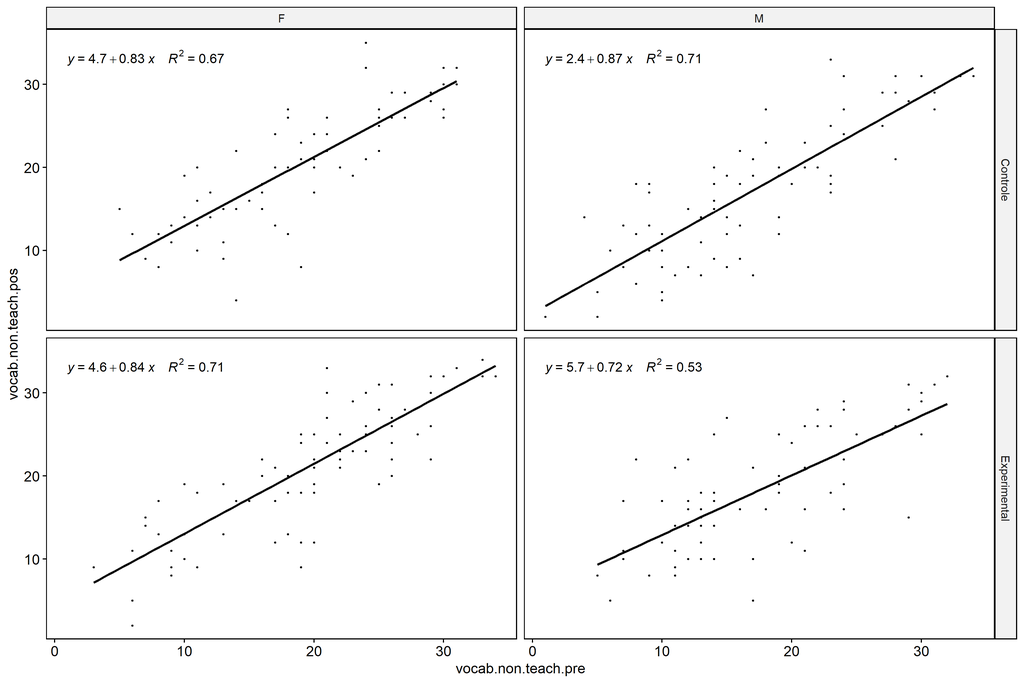

```r
ggscatter(wdat, x = "vocab.non.teach.pre", y = "vocab.non.teach.pos", size = 0.5,
          facet.by = c("grupo","Sexo"), add = "reg.line")+
  stat_regline_equation(
    aes(label =  paste(..eq.label.., ..rr.label.., sep = "~~~~"))
  )
```

### Checking normality and homogeneity

```r
res <- augment(lm(vocab.non.teach.pos ~ vocab.non.teach.pre + grupo*Sexo, data = wdat))
```

```r
shapiro_test(res$.resid)
```

```
## # A tibble: 1 × 3
##   variable   statistic p.value
##   <chr>          <dbl>   <dbl>
## 1 res$.resid     0.990  0.0452
```

```r
levene_test(res, .resid ~ grupo*Sexo)
```

```
## # A tibble: 1 × 4
##     df1   df2 statistic     p
##   <int> <int>     <dbl> <dbl>
## 1     3   299     0.769 0.512
```

# ANCOVA and Pairwise for two factors **grupo:Zona**

## Without remove non-normal data

```r
pdat = remove_group_data(dat[!is.na(dat[["grupo"]]) & !is.na(dat[["Zona"]]),], "vocab.non.teach.pos", c("grupo","Zona"))

pdat.long <- rbind(pdat[,c("id","grupo","Zona")], pdat[,c("id","grupo","Zona")])
pdat.long[["time"]] <- c(rep("pre", nrow(pdat)), rep("pos", nrow(pdat)))
pdat.long[["time"]] <- factor(pdat.long[["time"]], c("pre","pos"))
pdat.long[["vocab.non.teach"]] <- c(pdat[["vocab.non.teach.pre"]], pdat[["vocab.non.teach.pos"]])

aov = anova_test(pdat, vocab.non.teach.pos ~ vocab.non.teach.pre + grupo*Zona)
laov[["grupo:Zona"]] <- get_anova_table(aov)
```

```r
pwcs <- list()
pwcs[["Zona"]] <- emmeans_test(
  group_by(pdat, grupo), vocab.non.teach.pos ~ Zona,
  covariate = vocab.non.teach.pre, p.adjust.method = "bonferroni")
pwcs[["grupo"]] <- emmeans_test(
  group_by(pdat, Zona), vocab.non.teach.pos ~ grupo,
  covariate = vocab.non.teach.pre, p.adjust.method = "bonferroni")

pwc <- plyr::rbind.fill(pwcs[["grupo"]], pwcs[["Zona"]])
pwc <- pwc[,c("grupo","Zona", colnames(pwc)[!colnames(pwc) %in% c("grupo","Zona")])]
```

```r
pwc.long <- emmeans_test(dplyr::group_by_at(pdat.long, c("grupo","Zona")),
                         vocab.non.teach ~ time,
                         p.adjust.method = "bonferroni")
lpwc[["grupo:Zona"]] <- plyr::rbind.fill(pwc, pwc.long)
```

```r
ds <- get.descriptives(pdat, "vocab.non.teach.pos", c("grupo","Zona"), covar = "vocab.non.teach.pre")
ds <- merge(ds[ds$variable != "vocab.non.teach.pre",],
            ds[ds$variable == "vocab.non.teach.pre", !colnames(ds) %in% c("variable")],
            by = c("grupo","Zona"), all.x = T, suffixes = c("", ".vocab.non.teach.pre"))
ds <- merge(get_emmeans(pwcs[["grupo"]]), ds, by = c("grupo","Zona"), suffixes = c(".emms", ""))
ds <- ds[,c("grupo","Zona","n","mean.vocab.non.teach.pre","se.vocab.non.teach.pre","mean","se","emmean","se.emms")]

colnames(ds) <- c("grupo","Zona", "N", paste0(c("M","SE")," (pre)"),
                  paste0(c("M","SE"), " (unadj)"), paste0(c("M", "SE"), " (adj)"))

lemms[["grupo:Zona"]] <- ds
```

## Computing ANCOVA and PairWise After removing non-normal data (OK)

```r
wdat = pdat

res = residuals(lm(vocab.non.teach.pos ~ vocab.non.teach.pre + grupo*Zona, data = wdat))
non.normal = getNonNormal(res, wdat$id, plimit = 0.05)

wdat = wdat[!wdat$id %in% non.normal,]

wdat.long <- rbind(wdat[,c("id","grupo","Zona")], wdat[,c("id","grupo","Zona")])
wdat.long[["time"]] <- c(rep("pre", nrow(wdat)), rep("pos", nrow(wdat)))
wdat.long[["time"]] <- factor(wdat.long[["time"]], c("pre","pos"))
wdat.long[["vocab.non.teach"]] <- c(wdat[["vocab.non.teach.pre"]], wdat[["vocab.non.teach.pos"]])


ldat[["grupo:Zona"]] = wdat

(non.normal)
```

```
## [1] "P852"  "P3473" "P3499" "P2856"
```

```r
aov = anova_test(wdat, vocab.non.teach.pos ~ vocab.non.teach.pre + grupo*Zona)
laov[["grupo:Zona"]] <- merge(get_anova_table(aov), laov[["grupo:Zona"]], by="Effect", suffixes = c("","'"))

(df = get_anova_table(aov))
```

```
## ANOVA Table (type II tests)
##
##                Effect DFn DFd       F        p p<.05      ges
## 1 vocab.non.teach.pre   1 239 414.802 3.83e-54     * 6.34e-01
## 2               grupo   1 239   0.013 9.10e-01       5.34e-05
## 3                Zona   1 239   0.891 3.46e-01       4.00e-03
## 4          grupo:Zona   1 239   0.047 8.29e-01       1.96e-04
```

| Effect | DFn | DFd | F | p | p<.05 | ges |
| --- | --- | --- | --- | --- | --- | --- |
| vocab.non.teach.pre | 1 | 239 | 414.802 | 0.000 | * | 0.634 |
| grupo | 1 | 239 | 0.013 | 0.910 |  | 0.000 |
| Zona | 1 | 239 | 0.891 | 0.346 |  | 0.004 |
| grupo:Zona | 1 | 239 | 0.047 | 0.829 |  | 0.000 |

```r
pwcs <- list()
pwcs[["Zona"]] <- emmeans_test(
  group_by(wdat, grupo), vocab.non.teach.pos ~ Zona,
  covariate = vocab.non.teach.pre, p.adjust.method = "bonferroni")
pwcs[["grupo"]] <- emmeans_test(
  group_by(wdat, Zona), vocab.non.teach.pos ~ grupo,
  covariate = vocab.non.teach.pre, p.adjust.method = "bonferroni")

pwc <- plyr::rbind.fill(pwcs[["grupo"]], pwcs[["Zona"]])
pwc <- pwc[,c("grupo","Zona", colnames(pwc)[!colnames(pwc) %in% c("grupo","Zona")])]
```

| grupo | Zona | term | .y. | group1 | group2 | df | statistic | p | p.adj | p.adj.signif |
| --- | --- | --- | --- | --- | --- | --- | --- | --- | --- | --- |
|  | Rural | vocab.non.teach.pre*grupo | vocab.non.teach.pos | Controle | Experimental | 239 | 0.014 | 0.989 | 0.989 | ns |
|  | Urbana | vocab.non.teach.pre*grupo | vocab.non.teach.pos | Controle | Experimental | 239 | -0.244 | 0.808 | 0.808 | ns |
| Controle |  | vocab.non.teach.pre*Zona | vocab.non.teach.pos | Rural | Urbana | 239 | -0.483 | 0.630 | 0.630 | ns |
| Experimental |  | vocab.non.teach.pre*Zona | vocab.non.teach.pos | Rural | Urbana | 239 | -0.841 | 0.401 | 0.401 | ns |

```r
pwc.long <- emmeans_test(dplyr::group_by_at(wdat.long, c("grupo","Zona")),
                         vocab.non.teach ~ time,
                         p.adjust.method = "bonferroni")
lpwc[["grupo:Zona"]] <- merge(plyr::rbind.fill(pwc, pwc.long), lpwc[["grupo:Zona"]], by=c("grupo","Zona","term",".y.","group1","group2"), suffixes = c("","'"))
```

| grupo | Zona | term | .y. | group1 | group2 | df | statistic | p | p.adj | p.adj.signif |
| --- | --- | --- | --- | --- | --- | --- | --- | --- | --- | --- |
| Controle | Rural | time | vocab.non.teach | pre | pos | 480 | -0.732 | 0.464 | 0.464 | ns |
| Controle | Urbana | time | vocab.non.teach | pre | pos | 480 | -0.518 | 0.605 | 0.605 | ns |
| Experimental | Rural | time | vocab.non.teach | pre | pos | 480 | -0.715 | 0.475 | 0.475 | ns |
| Experimental | Urbana | time | vocab.non.teach | pre | pos | 480 | -0.683 | 0.495 | 0.495 | ns |

```r
ds <- get.descriptives(wdat, "vocab.non.teach.pos", c("grupo","Zona"), covar = "vocab.non.teach.pre")
ds <- merge(ds[ds$variable != "vocab.non.teach.pre",],
            ds[ds$variable == "vocab.non.teach.pre", !colnames(ds) %in% c("variable")],
            by = c("grupo","Zona"), all.x = T, suffixes = c("", ".vocab.non.teach.pre"))
ds <- merge(get_emmeans(pwcs[["grupo"]]), ds, by = c("grupo","Zona"), suffixes = c(".emms", ""))
ds <- ds[,c("grupo","Zona","n","mean.vocab.non.teach.pre","se.vocab.non.teach.pre","mean","se","emmean","se.emms")]

colnames(ds) <- c("grupo","Zona", "N", paste0(c("M","SE")," (pre)"),
                  paste0(c("M","SE"), " (unadj)"), paste0(c("M", "SE"), " (adj)"))

lemms[["grupo:Zona"]] <- merge(ds, lemms[["grupo:Zona"]], by=c("grupo","Zona"), suffixes = c("","'"))
```

| grupo | Zona | N | M (pre) | SE (pre) | M (unadj) | SE (unadj) | M (adj) | SE (adj) |
| --- | --- | --- | --- | --- | --- | --- | --- | --- |
| Controle | Rural | 96 | 18.073 | 0.741 | 18.865 | 0.818 | 19.126 | 0.466 |
| Controle | Urbana | 28 | 19.250 | 1.684 | 20.286 | 1.433 | 19.599 | 0.863 |
| Experimental | Rural | 83 | 17.819 | 0.778 | 18.651 | 0.749 | 19.116 | 0.501 |
| Experimental | Urbana | 37 | 19.892 | 1.240 | 21.081 | 1.264 | 19.878 | 0.752 |

### Plots for ancova

```r
plots <- twoWayAncovaPlots(
  wdat, "vocab.non.teach.pos", c("grupo","Zona"), aov, pwcs, addParam = c("mean_se"),
  font.label.size=10, step.increase=0.05, p.label="p.adj",
  subtitle = which(aov$Effect == "grupo:Zona"))
```

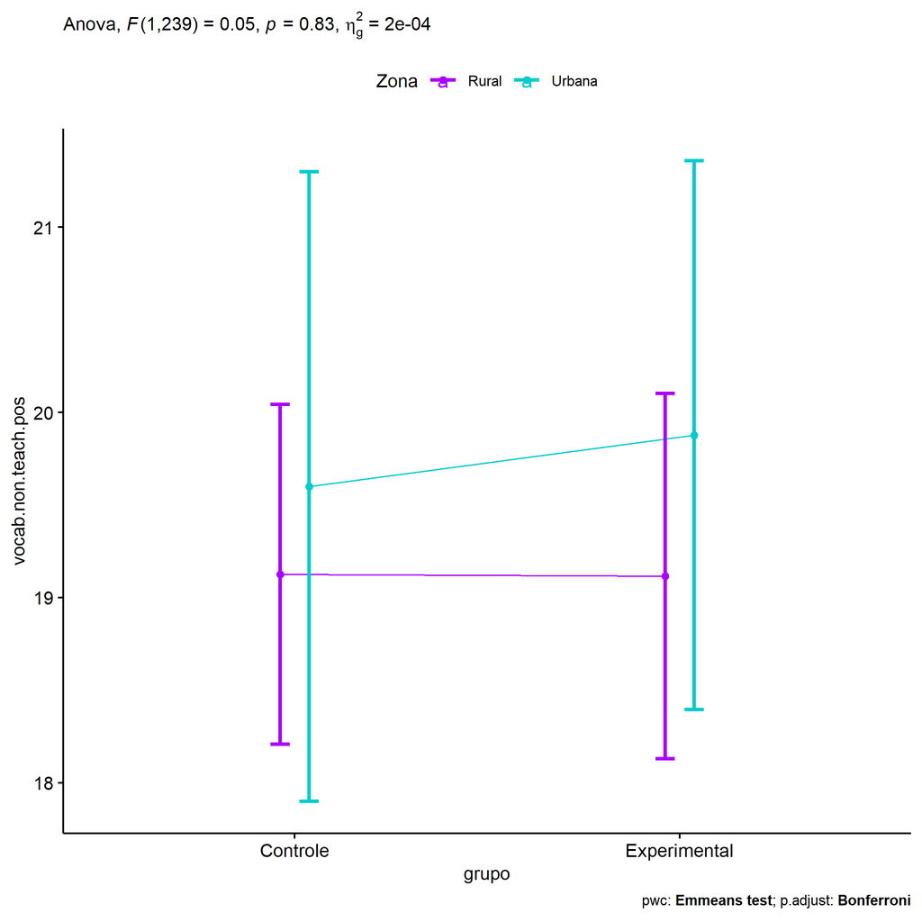

```r
if (!is.null(plots[["grupo"]]))
  plots[["grupo"]] + ggplot2::scale_color_manual(values = color[["Zona"]])
```

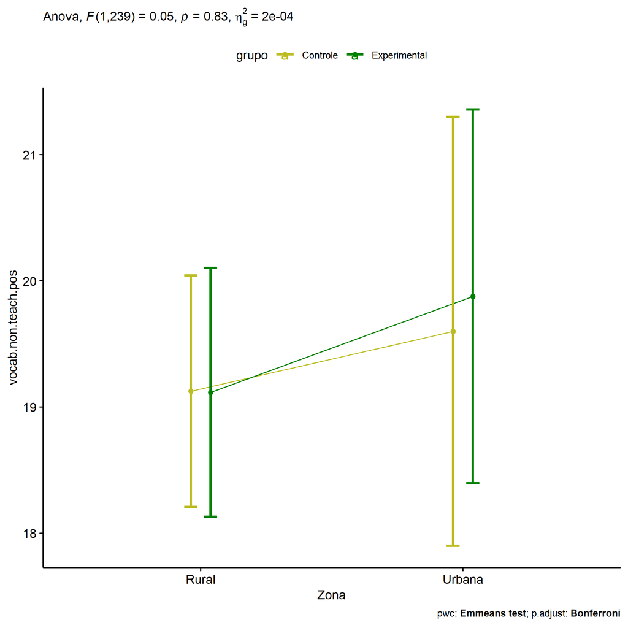

```r
if (!is.null(plots[["Zona"]]))
  plots[["Zona"]] + ggplot2::scale_color_manual(values = color[["grupo"]])
```

```r
plots <- twoWayAncovaBoxPlots(
  wdat, "vocab.non.teach.pos", c("grupo","Zona"), aov, pwcs, covar = "vocab.non.teach.pre",
  theme = "classic", color = color[["grupo:Zona"]],
  subtitle = which(aov$Effect == "grupo:Zona"))
```

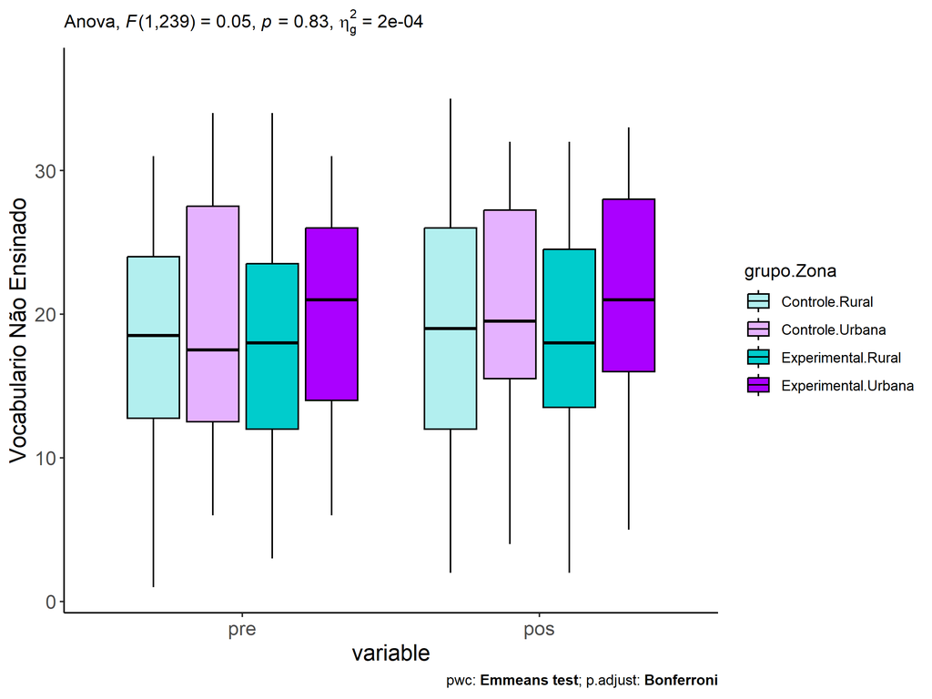

```r
plots[["grupo:Zona"]] + ggplot2::ylab("Vocabulario Não Ensinado") + ggplot2::scale_x_discrete(labels=c('pre', 'pos'))
```

```r
plots <- twoWayAncovaBoxPlots(
  wdat.long, "vocab.non.teach", c("grupo","Zona"), aov, pwc.long, pre.post = "time",
  theme = "classic", color = color$prepost)
```

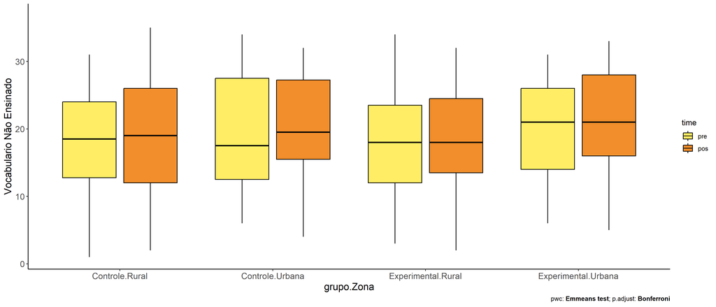

```r
plots[["grupo:Zona"]] + ggplot2::ylab("Vocabulario Não Ensinado")
```

### Checking linearity assumption

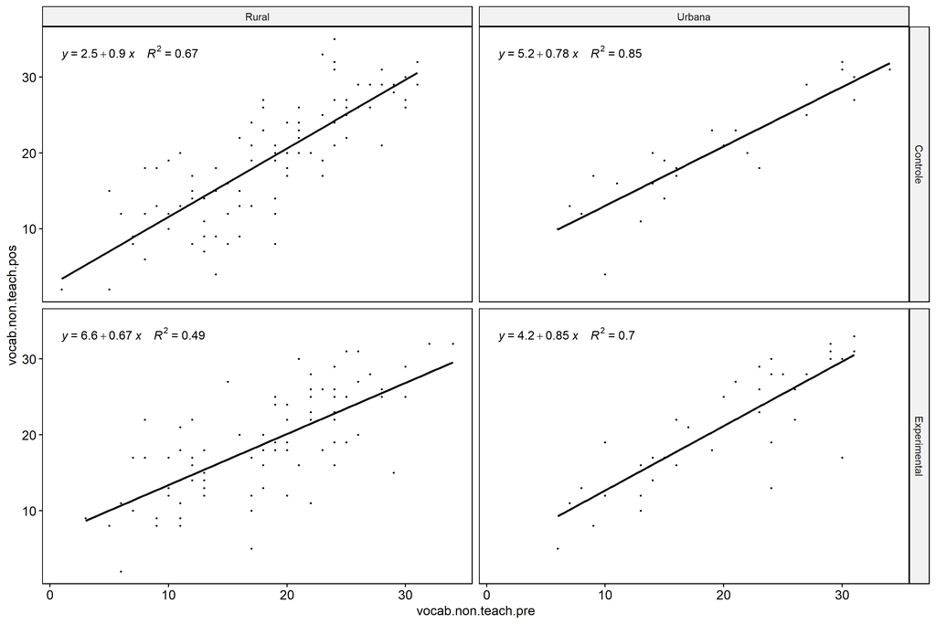

```r
ggscatter(wdat, x = "vocab.non.teach.pre", y = "vocab.non.teach.pos", size = 0.5,
          facet.by = c("grupo","Zona"), add = "reg.line")+
  stat_regline_equation(
    aes(label =  paste(..eq.label.., ..rr.label.., sep = "~~~~"))
  )
```

### Checking normality and homogeneity

```r
res <- augment(lm(vocab.non.teach.pos ~ vocab.non.teach.pre + grupo*Zona, data = wdat))
```

```r
shapiro_test(res$.resid)
```

```
## # A tibble: 1 × 3
##   variable   statistic p.value
##   <chr>          <dbl>   <dbl>
## 1 res$.resid     0.988  0.0438
```

```r
levene_test(res, .resid ~ grupo*Zona)
```

```
## # A tibble: 1 × 4
##     df1   df2 statistic      p
##   <int> <int>     <dbl>  <dbl>
## 1     3   240      2.61 0.0520
```

# ANCOVA and Pairwise for two factors **grupo:Cor.Raca**

## Without remove non-normal data

```r
pdat = remove_group_data(dat[!is.na(dat[["grupo"]]) & !is.na(dat[["Cor.Raca"]]),], "vocab.non.teach.pos", c("grupo","Cor.Raca"))
pdat.long <- rbind(pdat[,c("id","grupo","Cor.Raca")], pdat[,c("id","grupo","Cor.Raca")])
pdat.long[["time"]] <- c(rep("pre", nrow(pdat)), rep("pos", nrow(pdat)))
pdat.long[["time"]] <- factor(pdat.long[["time"]], c("pre","pos"))
pdat.long[["vocab.non.teach"]] <- c(pdat[["vocab.non.teach.pre"]], pdat[["vocab.non.teach.pos"]])

aov = anova_test(pdat, vocab.non.teach.pos ~ vocab.non.teach.pre + grupo*Cor.Raca)
laov[["grupo:Cor.Raca"]] <- get_anova_table(aov)
```

```r
pwcs <- list()
pwcs[["Cor.Raca"]] <- emmeans_test(
  group_by(pdat, grupo), vocab.non.teach.pos ~ Cor.Raca,
  covariate = vocab.non.teach.pre, p.adjust.method = "bonferroni")
pwcs[["grupo"]] <- emmeans_test(
  group_by(pdat, Cor.Raca), vocab.non.teach.pos ~ grupo,
  covariate = vocab.non.teach.pre, p.adjust.method = "bonferroni")

pwc <- plyr::rbind.fill(pwcs[["grupo"]], pwcs[["Cor.Raca"]])
pwc <- pwc[,c("grupo","Cor.Raca", colnames(pwc)[!colnames(pwc) %in% c("grupo","Cor.Raca")])]
```

```r
pwc.long <- emmeans_test(dplyr::group_by_at(pdat.long, c("grupo","Cor.Raca")),
                         vocab.non.teach ~ time,
                         p.adjust.method = "bonferroni")
lpwc[["grupo:Cor.Raca"]] <- plyr::rbind.fill(pwc, pwc.long)
```

```r
ds <- get.descriptives(pdat, "vocab.non.teach.pos", c("grupo","Cor.Raca"), covar = "vocab.non.teach.pre")
ds <- merge(ds[ds$variable != "vocab.non.teach.pre",],
            ds[ds$variable == "vocab.non.teach.pre", !colnames(ds) %in% c("variable")],
            by = c("grupo","Cor.Raca"), all.x = T, suffixes = c("", ".vocab.non.teach.pre"))
ds <- merge(get_emmeans(pwcs[["grupo"]]), ds, by = c("grupo","Cor.Raca"), suffixes = c(".emms", ""))
ds <- ds[,c("grupo","Cor.Raca","n","mean.vocab.non.teach.pre","se.vocab.non.teach.pre","mean","se","emmean","se.emms")]

colnames(ds) <- c("grupo","Cor.Raca", "N", paste0(c("M","SE")," (pre)"),
                  paste0(c("M","SE"), " (unadj)"), paste0(c("M", "SE"), " (adj)"))

lemms[["grupo:Cor.Raca"]] <- ds
```

## Computing ANCOVA and PairWise After removing non-normal data (OK)

```r
wdat = pdat

res = residuals(lm(vocab.non.teach.pos ~ vocab.non.teach.pre + grupo*Cor.Raca, data = wdat))
non.normal = getNonNormal(res, wdat$id, plimit = 0.05)

wdat = wdat[!wdat$id %in% non.normal,]

wdat.long <- rbind(wdat[,c("id","grupo","Cor.Raca")], wdat[,c("id","grupo","Cor.Raca")])
wdat.long[["time"]] <- c(rep("pre", nrow(wdat)), rep("pos", nrow(wdat)))
wdat.long[["time"]] <- factor(wdat.long[["time"]], c("pre","pos"))
wdat.long[["vocab.non.teach"]] <- c(wdat[["vocab.non.teach.pre"]], wdat[["vocab.non.teach.pos"]])


ldat[["grupo:Cor.Raca"]] = wdat

(non.normal)
```

[output not shown]

```r
aov = anova_test(wdat, vocab.non.teach.pos ~ vocab.non.teach.pre + grupo*Cor.Raca)
laov[["grupo:Cor.Raca"]] <- merge(get_anova_table(aov), laov[["grupo:Cor.Raca"]], by="Effect", suffixes = c("","'"))

(df = get_anova_table(aov))
```

```
## ANOVA Table (type II tests)
##
##                Effect DFn DFd       F        p p<.05   ges
## 1 vocab.non.teach.pre   1 133 204.336 1.16e-28     * 0.606
## 2               grupo   1 133   0.327 5.68e-01       0.002
## 3            Cor.Raca   2 133   1.054 3.52e-01       0.016
## 4      grupo:Cor.Raca   1 133   1.447 2.31e-01       0.011
```

| Effect | DFn | DFd | F | p | p<.05 | ges |
| --- | --- | --- | --- | --- | --- | --- |
| vocab.non.teach.pre | 1 | 133 | 204.336 | 0.000 | * | 0.606 |
| grupo | 1 | 133 | 0.327 | 0.568 |  | 0.002 |
| Cor.Raca | 2 | 133 | 1.054 | 0.352 |  | 0.016 |
| grupo:Cor.Raca | 1 | 133 | 1.447 | 0.231 |  | 0.011 |

```r
pwcs <- list()
pwcs[["Cor.Raca"]] <- emmeans_test(
  group_by(wdat, grupo), vocab.non.teach.pos ~ Cor.Raca,
  covariate = vocab.non.teach.pre, p.adjust.method = "bonferroni")
pwcs[["grupo"]] <- emmeans_test(
  group_by(wdat, Cor.Raca), vocab.non.teach.pos ~ grupo,
  covariate = vocab.non.teach.pre, p.adjust.method = "bonferroni")

pwc <- plyr::rbind.fill(pwcs[["grupo"]], pwcs[["Cor.Raca"]])
pwc <- pwc[,c("grupo","Cor.Raca", colnames(pwc)[!colnames(pwc) %in% c("grupo","Cor.Raca")])]
```

| grupo | Cor.Raca | term | .y. | group1 | group2 | df | statistic | p | p.adj | p.adj.signif |
| --- | --- | --- | --- | --- | --- | --- | --- | --- | --- | --- |
|  | Branca | vocab.non.teach.pre*grupo | vocab.non.teach.pos | Controle | Experimental | 133 | 0.674 | 0.501 | 0.501 | ns |
|  | Indígena | vocab.non.teach.pre*grupo | vocab.non.teach.pos | Controle | Experimental |  |  |  |  |  |
|  | Parda | vocab.non.teach.pre*grupo | vocab.non.teach.pos | Controle | Experimental | 133 | -1.148 | 0.253 | 0.253 | ns |
| Controle |  | vocab.non.teach.pre*Cor.Raca | vocab.non.teach.pos | Branca | Indígena |  |  |  |  |  |
| Controle |  | vocab.non.teach.pre*Cor.Raca | vocab.non.teach.pos | Branca | Parda | 133 | 0.012 | 0.991 | 0.991 | ns |
| Controle |  | vocab.non.teach.pre*Cor.Raca | vocab.non.teach.pos | Indígena | Parda |  |  |  |  |  |
| Experimental |  | vocab.non.teach.pre*Cor.Raca | vocab.non.teach.pos | Branca | Indígena | 133 | -1.691 | 0.093 | 0.280 | ns |
| Experimental |  | vocab.non.teach.pre*Cor.Raca | vocab.non.teach.pos | Branca | Parda | 133 | -1.629 | 0.106 | 0.317 | ns |
| Experimental |  | vocab.non.teach.pre*Cor.Raca | vocab.non.teach.pos | Indígena | Parda | 133 | 0.509 | 0.611 | 1.000 | ns |

```r
pwc.long <- emmeans_test(dplyr::group_by_at(wdat.long, c("grupo","Cor.Raca")),
                         vocab.non.teach ~ time,
                         p.adjust.method = "bonferroni")
lpwc[["grupo:Cor.Raca"]] <- merge(plyr::rbind.fill(pwc, pwc.long), lpwc[["grupo:Cor.Raca"]], by=c("grupo","Cor.Raca","term",".y.","group1","group2"), suffixes = c("","'"))
```

| grupo | Cor.Raca | term | .y. | group1 | group2 | df | statistic | p | p.adj | p.adj.signif |
| --- | --- | --- | --- | --- | --- | --- | --- | --- | --- | --- |
| Controle | Branca | time | vocab.non.teach | pre | pos | 268 | -0.102 | 0.919 | 0.919 | ns |
| Controle | Indígena | time | vocab.non.teach | pre | pos |  |  |  |  |  |
| Controle | Parda | time | vocab.non.teach | pre | pos | 268 | -0.311 | 0.756 | 0.756 | ns |
| Experimental | Branca | time | vocab.non.teach | pre | pos | 268 | 0.430 | 0.668 | 0.668 | ns |
| Experimental | Indígena | time | vocab.non.teach | pre | pos | 268 | -0.878 | 0.381 | 0.381 | ns |
| Experimental | Parda | time | vocab.non.teach | pre | pos | 268 | -1.027 | 0.306 | 0.306 | ns |

```r
ds <- get.descriptives(wdat, "vocab.non.teach.pos", c("grupo","Cor.Raca"), covar = "vocab.non.teach.pre")
ds <- merge(ds[ds$variable != "vocab.non.teach.pre",],
            ds[ds$variable == "vocab.non.teach.pre", !colnames(ds) %in% c("variable")],
            by = c("grupo","Cor.Raca"), all.x = T, suffixes = c("", ".vocab.non.teach.pre"))
ds <- merge(get_emmeans(pwcs[["grupo"]]), ds, by = c("grupo","Cor.Raca"), suffixes = c(".emms", ""))
ds <- ds[,c("grupo","Cor.Raca","n","mean.vocab.non.teach.pre","se.vocab.non.teach.pre","mean","se","emmean","se.emms")]

colnames(ds) <- c("grupo","Cor.Raca", "N", paste0(c("M","SE")," (pre)"),
                  paste0(c("M","SE"), " (unadj)"), paste0(c("M", "SE"), " (adj)"))

lemms[["grupo:Cor.Raca"]] <- merge(ds, lemms[["grupo:Cor.Raca"]], by=c("grupo","Cor.Raca"), suffixes = c("","'"))
```

| grupo | Cor.Raca | N | M (pre) | SE (pre) | M (unadj) | SE (unadj) | M (adj) | SE (adj) |
| --- | --- | --- | --- | --- | --- | --- | --- | --- |
| Controle | Branca | 22 | 19.227 | 1.331 | 19.455 | 1.552 | 18.647 | 1.029 |
| Controle | Parda | 42 | 17.429 | 1.202 | 17.929 | 1.279 | 18.632 | 0.746 |
| Experimental | Branca | 18 | 20.778 | 1.560 | 19.722 | 2.175 | 17.612 | 1.146 |
| Experimental | Indígena | 13 | 17.000 | 1.941 | 19.538 | 2.027 | 20.602 | 1.339 |
| Experimental | Parda | 44 | 17.932 | 1.051 | 19.545 | 0.980 | 19.826 | 0.727 |